# DANL 310 Lecture 08

February 22, 2022

## Add labels, make notes, and work with models

## The `gss_sm` data and summary

- The `socviz` package includes the `gss_sm` data frame.
  - `gss_sm` is a dataset containing an extract from the 2016 General Social Survey.
- Summarize the relative frequencies of educational degrees by race.
  - The sum of the relative frequencies of educational degrees is one for each race.

```r
library(tidyverse)
library(socviz)
library(gapminder)
library(skimr)
library(ggrepel)
library(ggthemes)
theme_set(theme_minimal())
view(gss_sm)
```

## The `gss_sm` data and summary

```
## # A tibble: 18 × 4
## # Groups:   race [3]
##    race  degree             N   pct
##    <fct> <fct>          <int> <dbl>
##  1 White Lt High School   197     9
##  2 White High School     1057    50
##  3 White Junior College   166     8
##  4 White Bachelor         426    20
##  5 White Graduate         250    12
##  6 White <NA>               4     0
##  7 Black Lt High School    60    12
##  8 Black High School      292    60
##  9 Black Junior College    33     7
## 10 Black Bachelor          71    14
## 11 Black Graduate          31     6
## 12 Black <NA>               3     1
## 13 Other Lt High School    71    26
## 14 Other High School      112    40
## 15 Other Junior College    17     6
## 16 Other Bachelor          39    14
## 17 Other Graduate          37    13
## 18 Other <NA>               1     0
```

## The `organdata` data

- The `socviz` package includes the `organdata` data frame.
  - `organdata` contains a little more than a decade’s worth of information on the donation of organs for transplants in seventeen OECD countries.

```r
library(tidyverse)
library(socviz)
library(skimr)
library(ggrepel)
theme_set(theme_minimal())

?organdata
glimpse(organdata)
```

```
## Rows: 238
## Columns: 21
## $ country          <chr> "Australia", "Australia", "Australia", "Australia", "…
## $ year             <date> NA, 1991-01-01, 1992-01-01, 1993-01-01, 1994-01-01, …
## $ donors           <dbl> NA, 12.09, 12.35, 12.51, 10.25, 10.18, 10.59, 10.26, …
## $ pop              <int> 17065, 17284, 17495, 17667, 17855, 18072, 18311, 1851…
## $ pop_dens         <dbl> 0.2204433, 0.2232723, 0.2259980, 0.2282198, 0.2306484…
## $ gdp              <int> 16774, 17171, 17914, 18883, 19849, 21079, 21923, 2296…
## $ gdp_lag          <int> 16591, 16774, 17171, 17914, 18883, 19849, 21079, 2192…
## $ health           <dbl> 1300, 1379, 1455, 1540, 1626, 1737, 1846, 1948, 2077,…
## $ health_lag       <dbl> 1224, 1300, 1379, 1455, 1540, 1626, 1737, 1846, 1948,…
## $ pubhealth        <dbl> 4.8, 5.4, 5.4, 5.4, 5.4, 5.5, 5.6, 5.7, 5.9, 6.1, 6.2…
## $ roads            <dbl> 136.59537, 122.25179, 112.83224, 110.54508, 107.98096…
## $ cerebvas         <int> 682, 647, 630, 611, 631, 592, 576, 525, 516, 493, 474…
## $ assault          <int> 21, 19, 17, 18, 17, 16, 17, 17, 16, 15, 16, 15, 14, N…
## $ external         <int> 444, 425, 406, 376, 387, 371, 395, 385, 410, 409, 393…
## $ txp_pop          <dbl> 0.9375916, 0.9257116, 0.9145470, 0.9056433, 0.8961075…
## $ world            <chr> "Liberal", "Liberal", "Liberal", "Liberal", "Liberal"…
## $ opt              <chr> "In", "In", "In", "In", "In", "In", "In", "In", "In",…
## $ consent_law      <chr> "Informed", "Informed", "Informed", "Informed", "Info…
## $ consent_practice <chr> "Informed", "Informed", "Informed", "Informed", "Info…
## $ consistent       <chr> "Yes", "Yes", "Yes", "Yes", "Yes", "Yes", "Yes", "Yes…
## $ ccode            <chr> "Oz", "Oz", "Oz", "Oz", "Oz", "Oz", "Oz", "Oz", "Oz",…
```

```r
skim(organdata)
```

Data summary

| Name | organdata |
| --- | --- |
| Number of rows | 238 |
| Number of columns | 21 |
| _______________________ |  |
| Column type frequency: |  |
| character | 7 |
| Date | 1 |
| numeric | 13 |
| ________________________ |  |
| Group variables | None |

**Variable type: character**

| skim_variable | n_missing | complete_rate | min | max | empty | n_unique | whitespace |
| --- | --- | --- | --- | --- | --- | --- | --- |
| country | 0 | 1.00 | 5 | 14 | 0 | 17 | 0 |
| world | 14 | 0.94 | 6 | 11 | 0 | 3 | 0 |
| opt | 28 | 0.88 | 2 | 3 | 0 | 2 | 0 |
| consent_law | 0 | 1.00 | 8 | 8 | 0 | 2 | 0 |
| consent_practice | 0 | 1.00 | 8 | 8 | 0 | 2 | 0 |
| consistent | 0 | 1.00 | 2 | 3 | 0 | 2 | 0 |
| ccode | 0 | 1.00 | 2 | 4 | 0 | 17 | 0 |

**Variable type: Date**

| skim_variable | n_missing | complete_rate | min | max | median | n_unique |
| --- | --- | --- | --- | --- | --- | --- |
| year | 34 | 0.86 | 1991-01-01 | 2002-01-01 | 1996-07-02 | 12 |

**Variable type: numeric**

| skim_variable | n_missing | complete_rate | mean | sd | p0 | p25 | p50 | p75 | p100 | hist |
| --- | --- | --- | --- | --- | --- | --- | --- | --- | --- | --- |
| donors | 34 | 0.86 | 16.48 | 5.11 | 5.20 | 13.00 | 15.10 | 19.60 | 33.90 | ▁▇▅▂▁ |
| pop | 17 | 0.93 | 39921.29 | 62219.22 | 3514.00 | 6938.00 | 15531.00 | 57301.00 | 288369.00 | ▇▁▁▁▁ |
| pop_dens | 17 | 0.93 | 12.00 | 11.09 | 0.22 | 1.94 | 9.49 | 19.11 | 38.89 | ▇▃▃▂▁ |
| gdp | 17 | 0.93 | 22986.18 | 4665.92 | 12917.00 | 19546.00 | 22756.00 | 26180.00 | 36554.00 | ▂▇▇▃▁ |
| gdp_lag | 0 | 1.00 | 22574.92 | 4790.71 | 11434.00 | 19034.25 | 22158.00 | 25886.50 | 36554.00 | ▂▇▇▃▁ |
| health | 0 | 1.00 | 2073.75 | 733.59 | 791.00 | 1581.00 | 1956.00 | 2407.50 | 5665.00 | ▆▇▂▁▁ |
| health_lag | 0 | 1.00 | 1972.99 | 699.24 | 727.00 | 1542.00 | 1850.50 | 2290.25 | 5267.00 | ▆▇▂▁▁ |
| pubhealth | 21 | 0.91 | 6.19 | 0.92 | 4.30 | 5.50 | 6.00 | 6.90 | 8.80 | ▂▇▅▃▁ |
| roads | 17 | 0.93 | 113.04 | 36.33 | 58.21 | 83.46 | 111.22 | 139.57 | 232.48 | ▇▇▆▂▁ |
| cerebvas | 17 | 0.93 | 610.80 | 144.45 | 300.00 | 500.00 | 604.00 | 698.00 | 957.00 | ▂▅▇▃▂ |
| assault | 17 | 0.93 | 16.53 | 17.33 | 4.00 | 9.00 | 11.00 | 16.00 | 103.00 | ▇▁▁▁▁ |
| external | 17 | 0.93 | 450.06 | 118.19 | 258.00 | 367.00 | 421.00 | 534.00 | 853.00 | ▆▇▅▁▁ |
| txp_pop | 17 | 0.93 | 0.72 | 0.20 | 0.22 | 0.63 | 0.71 | 0.83 | 1.12 | ▁▂▇▃▃ |

```r
view(organdata)
```

## Continuous variables by group or category

- What we would like to do is apply the `mean()` and `sd()` functions to every numerical variable in `organdata`, but only the numerical ones.
- `summarize_if()` examines each column in our data and applies a test to it.
  - `summarize_if()` only summarizes if the test is passed, that is, if it returns a value of `TRUE`.

## Continuous variables by group or category

```r
by_country <- organdata %>% group_by(consent_law, country) %>%
    summarize_if(is.numeric, funs(mean, sd), na.rm = TRUE) %>%
    ungroup()

by_country
```

```
## # A tibble: 17 × 28
##    consent_law country  donors_mean pop_mean pop_dens_mean gdp_mean gdp_lag_mean
##    <chr>       <chr>          <dbl>    <dbl>         <dbl>    <dbl>        <dbl>
##  1 Informed    Austral…        10.6   18318.         0.237   22179.       21779.
##  2 Informed    Canada          14.0   29608.         0.297   23711.       23353.
##  3 Informed    Denmark         13.1    5257.        12.2     23722.       23275
##  4 Informed    Germany         13.0   80255.        22.5     22163.       21938.
##  5 Informed    Ireland         19.8    3674.         5.23    20824.       20154.
##  6 Informed    Netherl…        13.7   15548.        37.4     23013.       22554.
##  7 Informed    United …        13.5   58187.        24.0     21359.       20962.
##  8 Informed    United …        20.0  269330.         2.80    29212.       28699.
##  9 Presumed    Austria         23.5    7927.         9.45    23876.       23415.
## 10 Presumed    Belgium         21.9   10153.        30.7     22500.       22096.
## 11 Presumed    Finland         18.4    5112.         1.51    21019.       20763
## 12 Presumed    France          16.8   58056.        10.5     22603.       22211.
## 13 Presumed    Italy           11.1   57360.        19.0     21554.       21195.
## 14 Presumed    Norway          15.4    4386.         1.35    26448.       25769.
## 15 Presumed    Spain           28.1   39666.         7.84    16933        16584.
## 16 Presumed    Sweden          13.1    8789.         1.95    22415.       22094
## 17 Presumed    Switzer…        14.2    7037.        17.0     27233        26931.
## # … with 21 more variables: health_mean <dbl>, health_lag_mean <dbl>,
## #   pubhealth_mean <dbl>, roads_mean <dbl>, cerebvas_mean <dbl>,
## #   assault_mean <dbl>, external_mean <dbl>, txp_pop_mean <dbl>,
## #   donors_sd <dbl>, pop_sd <dbl>, pop_dens_sd <dbl>, gdp_sd <dbl>,
## #   gdp_lag_sd <dbl>, health_sd <dbl>, health_lag_sd <dbl>, pubhealth_sd <dbl>,
## #   roads_sd <dbl>, cerebvas_sd <dbl>, assault_sd <dbl>, external_sd <dbl>,
## #   txp_pop_sd <dbl>
```

## Cleveland dotplot

```r
p <- ggplot(data = by_country,
            mapping = aes(x = donors_mean, y = reorder(country, donors_mean),
                          color = consent_law))
p + geom_point(size=3) +
    labs(x = "Donor Procurement Rate",
         y = "", color = "Consent Law") +
    theme(legend.position="top")
```

- **Cleveland dotplot** is a simple and extremely effective method of presenting data that is usually better than either a bar chart or a table.

## Cleveland dotplot

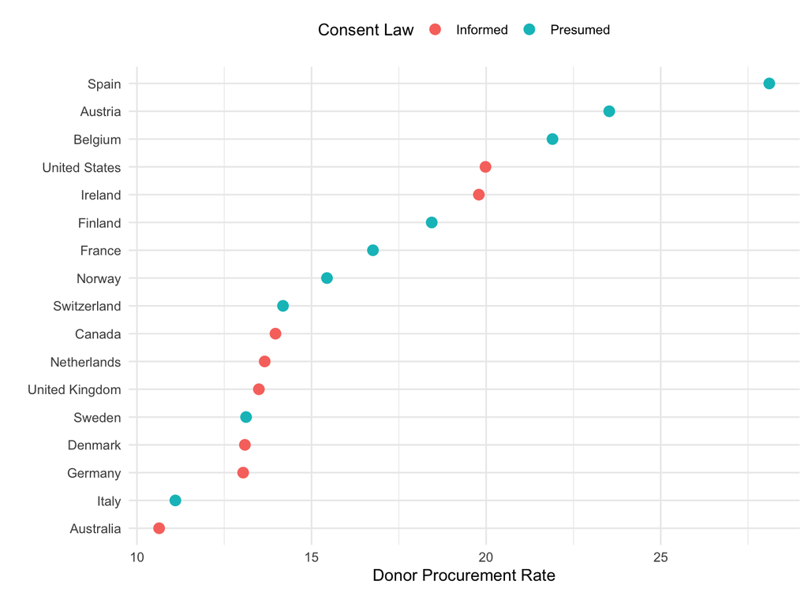

## Plot text directly

```r
p_title <- "Presidential Elections: Popular & Electoral College Margins"
p_subtitle <- "1824-2016"
p_caption <- "Data for 2016 are provisional."
x_label <- "Winner's share of Popular Vote"
y_label <- "Winner's share of Electoral College Votes"
p <- ggplot(elections_historic, aes(x = popular_pct, y = ec_pct, label = winner_label))
p + geom_hline(yintercept = 0.5, size = 1.4, color = "gray80") +
    geom_vline(xintercept = 0.5, size = 1.4, color = "gray80") +
    geom_point() + geom_text_repel() +
    scale_x_continuous(labels = scales::percent) +
    scale_y_continuous(labels = scales::percent) +
    labs(x = x_label, y = y_label, title = p_title, subtitle = p_subtitle,
         caption = p_caption)
```

- `geom_hline()` and `geom_vline()` to make the lines.
- `geom_text_repel()` makes sure the labels do not overlap with each other, or obscure other points.

## Plot text directly

[figure not shown]

## Label outliers

```r
p <- ggplot(data = by_country,
            mapping = aes(x = gdp_mean, y = health_mean))

p + geom_point() +
    geom_text_repel(data = subset(by_country, gdp_mean > 25000),
                    mapping = aes(label = country))
```

- Sometimes we want to pick out some points of interest in the data without labeling every single item.
  - We do this using the `subset()` function.

## Label outliers

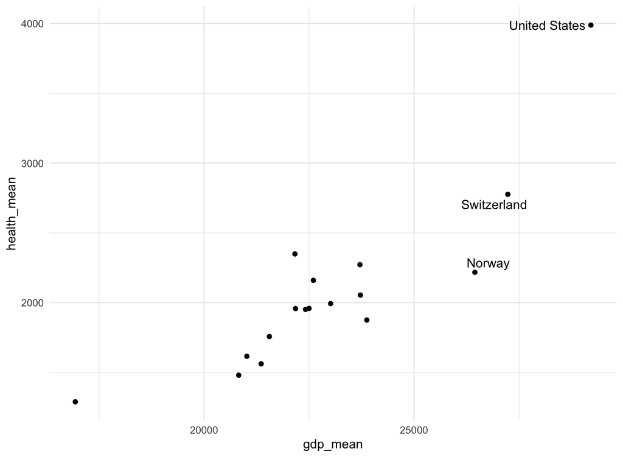

## Label outliers

```r
p + geom_point() +
    geom_text_repel(data = subset(by_country,
                                  gdp_mean > 25000 | health_mean < 1500 |
                                  country %in% "Belgium"),
                    mapping = aes(label = country))
```

## Label outliers

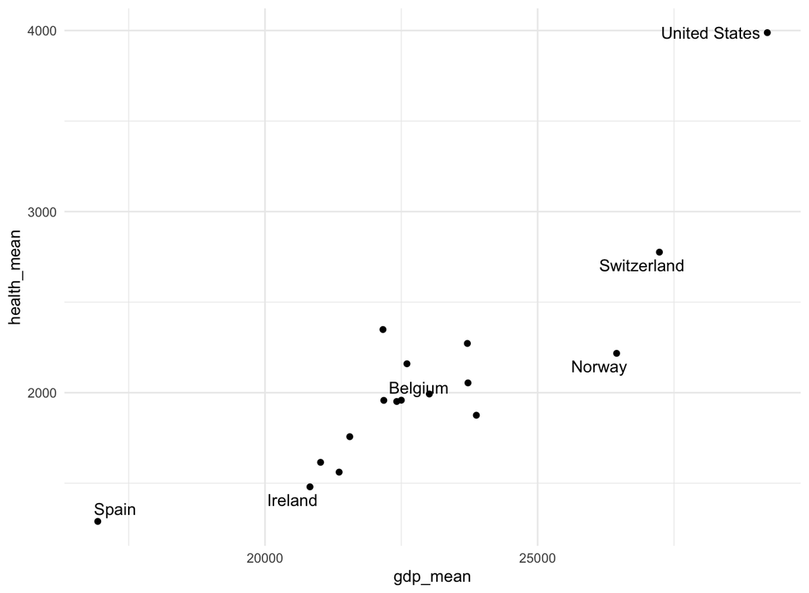

## Label outliers

```r
organdata$ind <- organdata$ccode %in% c("Ita", "Spa") &
                    organdata$year > 1998

p <- ggplot(data = organdata,
            mapping = aes(x = roads,
                          y = donors, color = ind))
p + geom_point() +
    geom_text_repel(data = subset(organdata, ind),
                    mapping = aes(label = ccode)) +
    guides(label = FALSE, color = FALSE)
```

## Label outliers

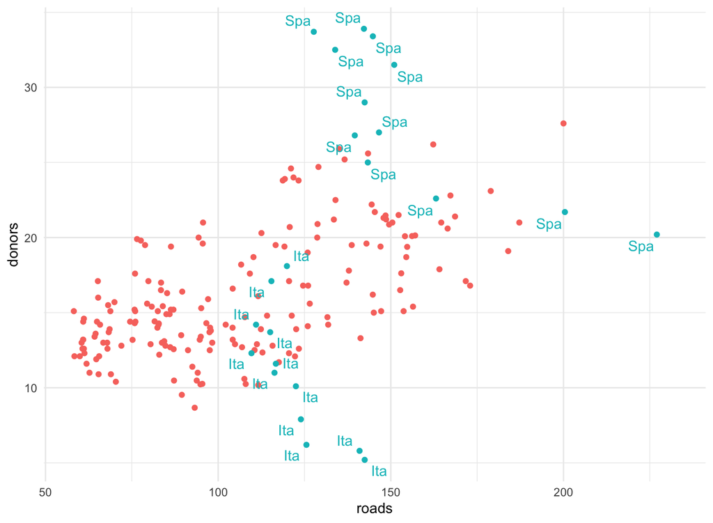

## Write and draw in the plot area

```r
p <- ggplot(data = organdata, mapping = aes(x = roads, y = donors))
p + geom_point() + annotate(geom = "text", x = 91, y = 33,
                            label = "A surprisingly high \n recovery rate.",
                            hjust = 0)
```

- Sometimes we want to annotate the figure directly.
  - We use `annotate()` to point out something important that is not mapped to a variable.

## Write and draw in the plot area

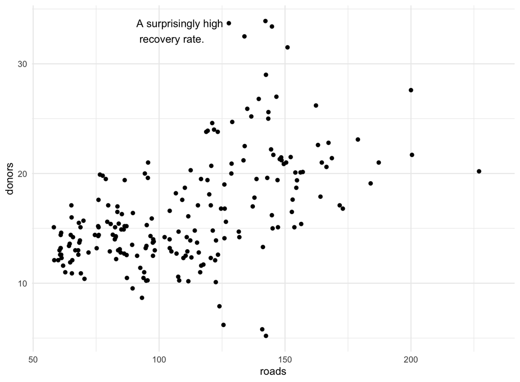

## Write and draw in the plot area

```r
p <- ggplot(data = organdata,
            mapping = aes(x = roads, y = donors))
p + geom_point() +
    annotate(geom = "rect", xmin = 125, xmax = 155,
             ymin = 30, ymax = 35, fill = "red", alpha = 0.2) +
    annotate(geom = "text", x = 157, y = 33,
             label = "A surprisingly high \n recovery rate.", hjust = 0)
```

- We can use `annotate()` to draw rectangles, line segments, and arrows.

## Write and draw in the plot area

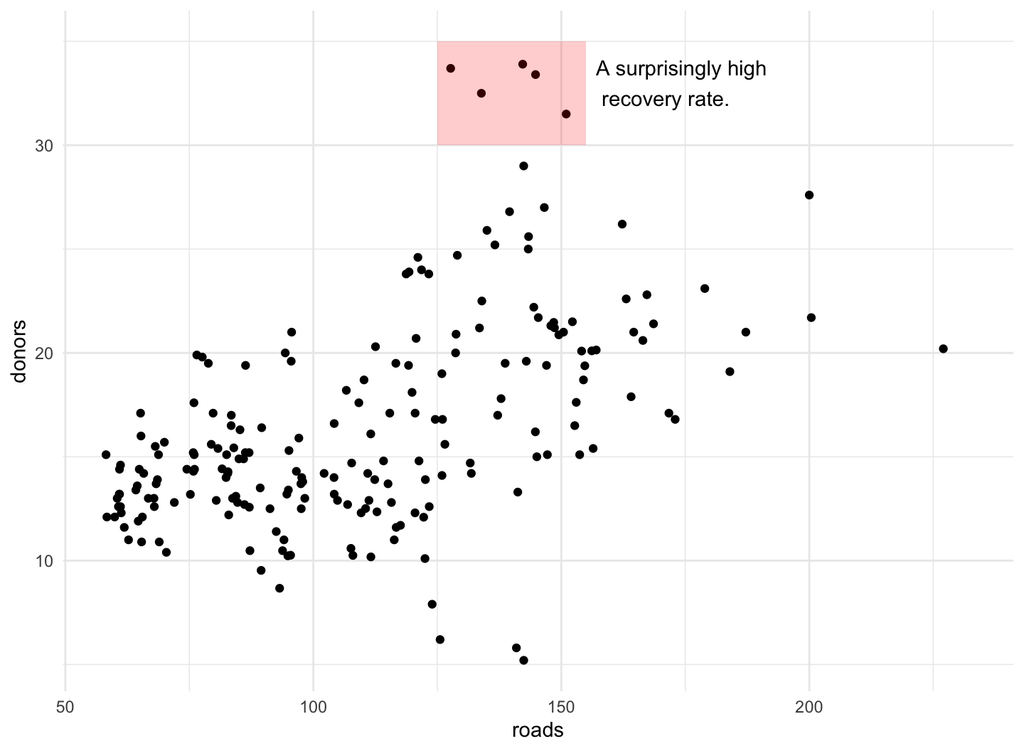

## Understanding scales, guides, and themes

- If you want to adjust how that scale is marked or graduated, then you use a `scale_` function.
  - \(\color{green}{\text{scale}}\)_\(\color{orange}{\text{<MAPPING>}}\)_\(\color{orange}{\text{<KIND>}}\)()
- The `guides()` function allows for adjustments to a legend or key to help the reader interpret the graph.
  - Making the legend disappear
  - Adjusting the arrangement of the key in legends and colorbars.
- The `theme()` function allows for adjustments to cosmetic features:
  - Background color
  - Typeface used for labels
  - Placement of the legend

## Understanding scales, guides, and themes

```r
p <- ggplot(data = organdata,
            mapping = aes(x = roads,
                          y = donors,
                          color = world))
p + geom_point()
```

- The `x` and `y` scales are both *continuous*.
- The `color` mapping also has a scale:
  - The `world` measure is an unordered categorical variable, so its scale is *discrete*.
- Mappings like `color`, `fill`, `shape`, and `size` have scales that we might want to customize or adjust.
  - If we want to adjust them, we use one of the `scale_` functions.

## Understanding scales, guides, and themes

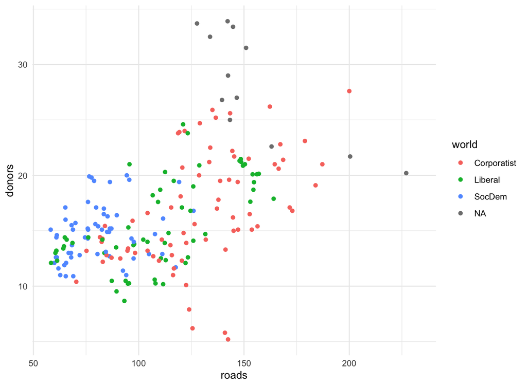

## Understanding scales, guides, and themes

```r
p <- ggplot(data = organdata,
            mapping = aes(x = roads,
                          y = donors,
                          color = world))
p + geom_point() +
    scale_x_log10() +
    scale_y_continuous(breaks = c(5, 15, 25),
                       labels = c("Five", "Fifteen", "Twenty Five"))
```

- We may end up with a lot of individual `scale_` functions:
  - `scale_x_continuous()` controls `x` scales for continuous variables.
  - `scale_y_discrete()` adjusts `y` scales for discrete variables.
  - `scale_x_log10()` transforms an `x` mapping to a base 10 log scale.
- If you want to adjust the labels or tick marks on a scale, you need to know which mapping it is for and what sort of scale it is.

## Understanding scales, guides, and themes

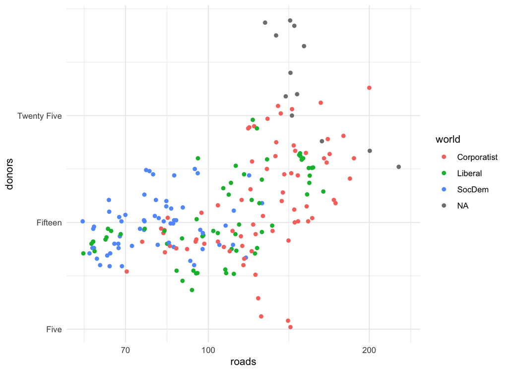

## Understanding scales, guides, and themes

```r
p <- ggplot(data = organdata,
            mapping = aes(x = roads,
                          y = donors,
                          color = world))
p + geom_point() +
    scale_color_discrete(labels =
                             c("Corporatist", "Liberal",
                               "Social Democratic", "Unclassified")) +
    labs(x = "Road Deaths",
         y = "Donor Procurement",
        color = "Welfare State")
```

- When working with a scale that produces a legend, we can also use appropriate `scale_` functions to specify the labels in the key.
- To change the title of the legend, however, we use the `labs()` function, which lets us label all the mappings.

## Understanding scales, guides, and themes

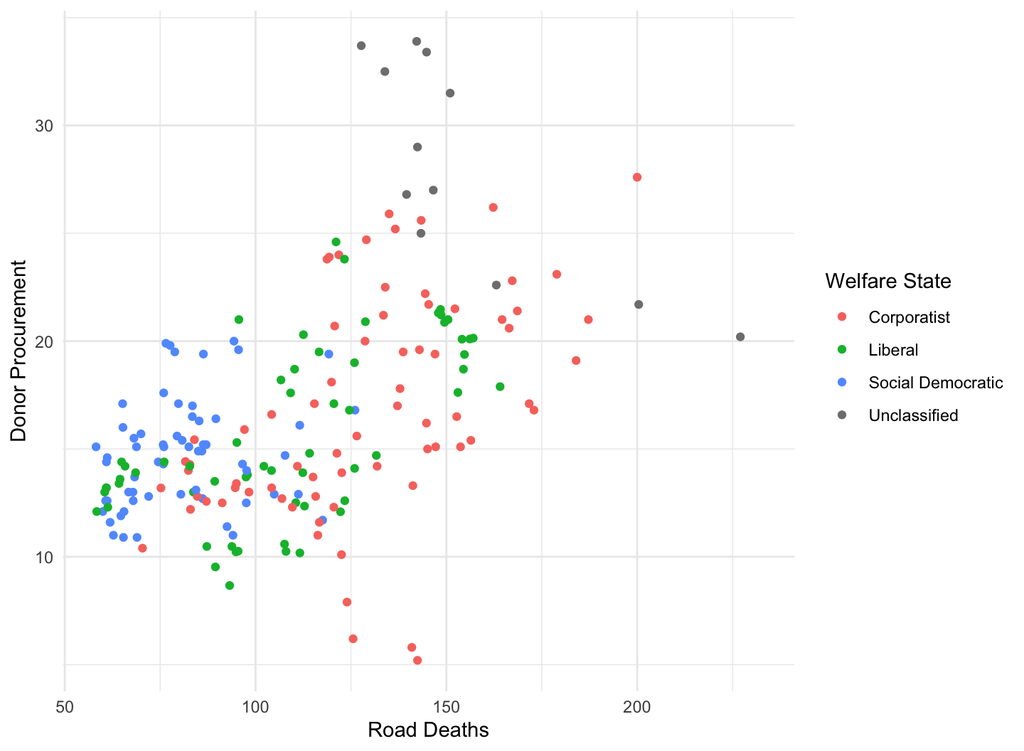

## Understanding scales, guides, and themes

```r
p <- ggplot(data = organdata,
            mapping = aes(x = roads,
                          y = donors,
                          color = world))
p + geom_point() +
    scale_color_discrete(labels =
                             c("Corporatist", "Liberal",
                               "Social Democratic", "Unclassified")) +
    labs(x = "Road Deaths",
         y = "Donor Procurement",
        color = "Welfare State")  +
    theme(legend.position = "top")
```

- Adding `+ theme(legend.position = "top")` will move the legend as instructed
- Adding `+ guides(color = "none")` make the legend disappear altogether here.

## Understanding scales, guides, and themes

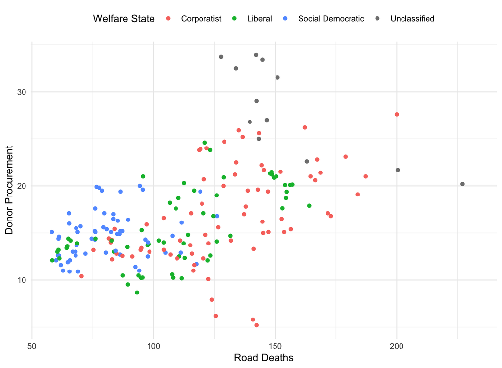

## gapminder data

- The `gapminder` package include the `gapminder` data frame.

```r
gapminder
```

```
## # A tibble: 1,704 × 6
##    country     continent  year lifeExp      pop gdpPercap
##    <fct>       <fct>     <int>   <dbl>    <int>     <dbl>
##  1 Afghanistan Asia       1952    28.8  8425333      779.
##  2 Afghanistan Asia       1957    30.3  9240934      821.
##  3 Afghanistan Asia       1962    32.0 10267083      853.
##  4 Afghanistan Asia       1967    34.0 11537966      836.
##  5 Afghanistan Asia       1972    36.1 13079460      740.
##  6 Afghanistan Asia       1977    38.4 14880372      786.
##  7 Afghanistan Asia       1982    39.9 12881816      978.
##  8 Afghanistan Asia       1987    40.8 13867957      852.
##  9 Afghanistan Asia       1992    41.7 16317921      649.
## 10 Afghanistan Asia       1997    41.8 22227415      635.
## # … with 1,694 more rows
```

```r
skim(gapminder)
```

Data summary

| Name | gapminder |
| --- | --- |
| Number of rows | 1704 |
| Number of columns | 6 |
| _______________________ |  |
| Column type frequency: |  |
| factor | 2 |
| numeric | 4 |
| ________________________ |  |
| Group variables | None |

**Variable type: factor**

| skim_variable | n_missing | complete_rate | ordered | n_unique | top_counts |
| --- | --- | --- | --- | --- | --- |
| country | 0 | 1 | FALSE | 142 | Afg: 12, Alb: 12, Alg: 12, Ang: 12 |
| continent | 0 | 1 | FALSE | 5 | Afr: 624, Asi: 396, Eur: 360, Ame: 300 |

**Variable type: numeric**

| skim_variable | n_missing | complete_rate | mean | sd | p0 | p25 | p50 | p75 | p100 | hist |
| --- | --- | --- | --- | --- | --- | --- | --- | --- | --- | --- |
| year | 0 | 1 | 1979.50 | 17.27 | 1952.00 | 1965.75 | 1979.50 | 1993.25 | 2007.0 | ▇▅▅▅▇ |
| lifeExp | 0 | 1 | 59.47 | 12.92 | 23.60 | 48.20 | 60.71 | 70.85 | 82.6 | ▁▆▇▇▇ |
| pop | 0 | 1 | 29601212.32 | 106157896.74 | 60011.00 | 2793664.00 | 7023595.50 | 19585221.75 | 1318683096.0 | ▇▁▁▁▁ |
| gdpPercap | 0 | 1 | 7215.33 | 9857.45 | 241.17 | 1202.06 | 3531.85 | 9325.46 | 113523.1 | ▇▁▁▁▁ |

```r
str(gapminder)
```

```
## tibble [1,704 × 6] (S3: tbl_df/tbl/data.frame)
##  $ country  : Factor w/ 142 levels "Afghanistan",..: 1 1 1 1 1 1 1 1 1 1 ...
##  $ continent: Factor w/ 5 levels "Africa","Americas",..: 3 3 3 3 3 3 3 3 3 3 ...
##  $ year     : int [1:1704] 1952 1957 1962 1967 1972 1977 1982 1987 1992 1997 ...
##  $ lifeExp  : num [1:1704] 28.8 30.3 32 34 36.1 ...
##  $ pop      : int [1:1704] 8425333 9240934 10267083 11537966 13079460 14880372 12881816 13867957 16317921 22227415 ...
##  $ gdpPercap: num [1:1704] 779 821 853 836 740 ...
```

- We can use the `str()` function to learn more about the internal structure of any object.

## Work with models

- Let us consider the linear regression of `lifeExp` on `gdpPercap`, `pop`, and `continent`.

```r
out <- lm(formula = lifeExp ~ gdpPercap + pop + continent,
          data = gapminder)

summary(out)
```

```
##
## Call:
## lm(formula = lifeExp ~ gdpPercap + pop + continent, data = gapminder)
##
## Residuals:
##     Min      1Q  Median      3Q     Max
## -49.161  -4.486   0.297   5.110  25.175
##
## Coefficients:
##                    Estimate Std. Error t value Pr(>|t|)
## (Intercept)       4.781e+01  3.395e-01 140.819  < 2e-16 ***
## gdpPercap         4.495e-04  2.346e-05  19.158  < 2e-16 ***
## pop               6.570e-09  1.975e-09   3.326 0.000901 ***
## continentAmericas 1.348e+01  6.000e-01  22.458  < 2e-16 ***
## continentAsia     8.193e+00  5.712e-01  14.342  < 2e-16 ***
## continentEurope   1.747e+01  6.246e-01  27.973  < 2e-16 ***
## continentOceania  1.808e+01  1.782e+00  10.146  < 2e-16 ***
## ---
## Signif. codes:  0 '***' 0.001 '**' 0.01 '*' 0.05 '.' 0.1 ' ' 1
##
## Residual standard error: 8.365 on 1697 degrees of freedom
## Multiple R-squared:  0.5821, Adjusted R-squared:  0.5806
## F-statistic: 393.9 on 6 and 1697 DF,  p-value: < 2.2e-16
```

```r
str(out)
```

```
## List of 13
##  $ coefficients : Named num [1:7] 4.78e+01 4.50e-04 6.57e-09 1.35e+01 8.19 ...
##   ..- attr(*, "names")= chr [1:7] "(Intercept)" "gdpPercap" "pop" "continentAmericas" ...
##  $ residuals    : Named num [1:1704] -27.6 -26.1 -24.5 -22.4 -20.3 ...
##   ..- attr(*, "names")= chr [1:1704] "1" "2" "3" "4" ...
##  $ effects      : Named num [1:1704] -2455.1 311.1 42.6 101.1 -17.2 ...
##   ..- attr(*, "names")= chr [1:1704] "(Intercept)" "gdpPercap" "pop" "continentAmericas" ...
##  $ rank         : int 7
##  $ fitted.values: Named num [1:1704] 56.4 56.4 56.5 56.5 56.4 ...
##   ..- attr(*, "names")= chr [1:1704] "1" "2" "3" "4" ...
##  $ assign       : int [1:7] 0 1 2 3 3 3 3
##  $ qr           :List of 5
##   ..$ qr   : num [1:1704, 1:7] -41.2795 0.0242 0.0242 0.0242 0.0242 ...
##   .. ..- attr(*, "dimnames")=List of 2
##   .. .. ..$ : chr [1:1704] "1" "2" "3" "4" ...
##   .. .. ..$ : chr [1:7] "(Intercept)" "gdpPercap" "pop" "continentAmericas" ...
##   .. ..- attr(*, "assign")= int [1:7] 0 1 2 3 3 3 3
##   .. ..- attr(*, "contrasts")=List of 1
##   .. .. ..$ continent: chr "contr.treatment"
##   ..$ qraux: num [1:7] 1.02 1.02 1 1.01 1.04 ...
##   ..$ pivot: int [1:7] 1 2 3 4 5 6 7
##   ..$ tol  : num 1e-07
##   ..$ rank : int 7
##   ..- attr(*, "class")= chr "qr"
##  $ df.residual  : int 1697
##  $ contrasts    :List of 1
##   ..$ continent: chr "contr.treatment"
##  $ xlevels      :List of 1
##   ..$ continent: chr [1:5] "Africa" "Americas" "Asia" "Europe" ...
##  $ call         : language lm(formula = lifeExp ~ gdpPercap + pop + continent, data = gapminder)
##  $ terms        :Classes 'terms', 'formula'  language lifeExp ~ gdpPercap + pop + continent
##   .. ..- attr(*, "variables")= language list(lifeExp, gdpPercap, pop, continent)
##   .. ..- attr(*, "factors")= int [1:4, 1:3] 0 1 0 0 0 0 1 0 0 0 ...
##   .. .. ..- attr(*, "dimnames")=List of 2
##   .. .. .. ..$ : chr [1:4] "lifeExp" "gdpPercap" "pop" "continent"
##   .. .. .. ..$ : chr [1:3] "gdpPercap" "pop" "continent"
##   .. ..- attr(*, "term.labels")= chr [1:3] "gdpPercap" "pop" "continent"
##   .. ..- attr(*, "order")= int [1:3] 1 1 1
##   .. ..- attr(*, "intercept")= int 1
##   .. ..- attr(*, "response")= int 1
```

[output cut: 9 more lines]

```
##   ..- attr(*, "terms")=Classes 'terms', 'formula'  language lifeExp ~ gdpPercap + pop + continent
##   .. .. ..- attr(*, "variables")= language list(lifeExp, gdpPercap, pop, continent)
##   .. .. ..- attr(*, "factors")= int [1:4, 1:3] 0 1 0 0 0 0 1 0 0 0 ...
##   .. .. .. ..- attr(*, "dimnames")=List of 2
##   .. .. .. .. ..$ : chr [1:4] "lifeExp" "gdpPercap" "pop" "continent"
##   .. .. .. .. ..$ : chr [1:3] "gdpPercap" "pop" "continent"
##   .. .. ..- attr(*, "term.labels")= chr [1:3] "gdpPercap" "pop" "continent"
##   .. .. ..- attr(*, "order")= int [1:3] 1 1 1
##   .. .. ..- attr(*, "intercept")= int 1
##   .. .. ..- attr(*, "response")= int 1
##   .. .. ..- attr(*, ".Environment")=<environment: R_GlobalEnv>
##   .. .. ..- attr(*, "predvars")= language list(lifeExp, gdpPercap, pop, continent)
##   .. .. ..- attr(*, "dataClasses")= Named chr [1:4] "numeric" "numeric" "numeric" "factor"
##   .. .. .. ..- attr(*, "names")= chr [1:4] "lifeExp" "gdpPercap" "pop" "continent"
##  - attr(*, "class")= chr "lm"
```

```r
out$coefficients
```

```
##       (Intercept)         gdpPercap               pop continentAmericas
##      4.781408e+01      4.495058e-04      6.569823e-09      1.347594e+01
##     continentAsia   continentEurope  continentOceania
##      8.192632e+00      1.747269e+01      1.808330e+01
```

```r
out$residuals
```

[output not shown]

[output cut: 627 more lines]

[output not shown]

```r
out$fitted.values
```

[output not shown]

[output cut: 371 more lines]

[output not shown]

## Generate predictions to graph

- Having fitted a model, then, we might want to get a picture of the predictions the model produces over the range of some particular variable.

```r
min_gdp <- min(gapminder$gdpPercap)
max_gdp <- max(gapminder$gdpPercap)
med_pop <- median(gapminder$pop)

pred_df <- expand.grid(gdpPercap = (seq(from = min_gdp,
                                        to = max_gdp,
                                        length.out = 100)),
                       pop = med_pop,
                       continent = c("Africa", "Americas",
                                     "Asia", "Europe", "Oceania"))

dim(pred_df)
```

```
## [1] 500   3
```

```r
head(pred_df)
```

```
##   gdpPercap     pop continent
## 1  241.1659 7023596    Africa
## 2 1385.4282 7023596    Africa
## 3 2529.6905 7023596    Africa
## 4 3673.9528 7023596    Africa
## 5 4818.2150 7023596    Africa
## 6 5962.4773 7023596    Africa
```

## Generate predictions to graph

- Now we can use `predict()`
  - It needs some new data to fit the model to.
  - If we specify `interval = 'predict'` as an argument, it will calculate 95% prediction intervals in addition to the point estimate.

```r
pred_out <- predict(object = out,
                    newdata = pred_df,
                    interval = "predict")
head(pred_out)
```

```
##        fit      lwr      upr
## 1 47.96863 31.54775 64.38951
## 2 48.48298 32.06231 64.90365
## 3 48.99733 32.57670 65.41797
## 4 49.51169 33.09092 65.93245
## 5 50.02604 33.60497 66.44711
## 6 50.54039 34.11885 66.96193
```

## Generate predictions to graph

- We can bind the two data frames, `pred_df` and `pred_out`, together by column.
- This is because `pred_df` and `pred_out` correspond row for row.

```r
pred_df <- cbind(pred_df, pred_out)
head(pred_df)
```

```
##   gdpPercap     pop continent      fit      lwr      upr
## 1  241.1659 7023596    Africa 47.96863 31.54775 64.38951
## 2 1385.4282 7023596    Africa 48.48298 32.06231 64.90365
## 3 2529.6905 7023596    Africa 48.99733 32.57670 65.41797
## 4 3673.9528 7023596    Africa 49.51169 33.09092 65.93245
## 5 4818.2150 7023596    Africa 50.02604 33.60497 66.44711
## 6 5962.4773 7023596    Africa 50.54039 34.11885 66.96193
```

## Generate predictions to graph

```r
p <- ggplot(data = subset(pred_df, continent %in% c("Europe", "Africa")),
            aes(x = gdpPercap,
                y = fit, ymin = lwr, ymax = upr,
                color = continent, fill = continent, group = continent))
p + geom_point(data = subset(gapminder,
                             continent %in% c("Europe", "Africa")),
               aes(x = gdpPercap, y = lifeExp,
                   color = continent),
               alpha = 0.5,
               inherit.aes = FALSE) +
    geom_line() +
    geom_ribbon(alpha = 0.2, color = FALSE) +
    scale_x_log10(labels = scales::dollar)
```

- `geom_ribbon()` draws the area covered by the prediction intervals:
  - It takes an `x` argument like a line, but a `ymin` and `ymax` argument as specified in the `ggplot()` aesthetic mapping.

## Generate predictions to graph

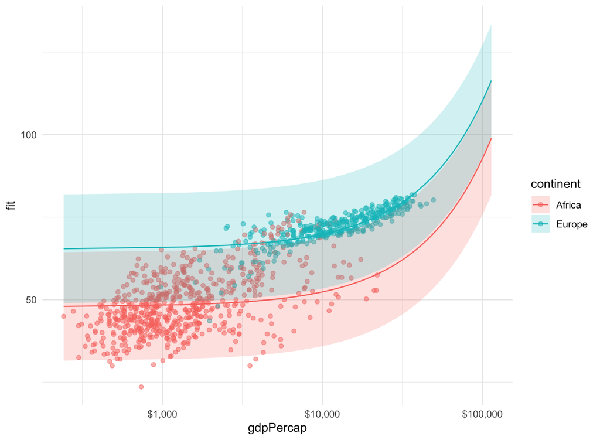

## Tidy model objects with `broom`

- The `broom` package to help us do a lot of things with our model output.
- `broom` can tidily extract three kinds of information.
  - We can see *component-level* information about aspects of the model itself, such as **coefficients** and **t-statistics**.
  - We can obtain *observation-level* information about the model’s connection to the underlying data, such as **fitted values** and **residuals**.
  - We can get *model-level* information that summarizes the fit as a whole, such as **F-statistic**, **model deviance**, or **r-squared**.

```r
library(broom)
```

## Get component-level statistics with `tidy()`

- The `tidy()` function takes a model object and returns a data frame of component-level information.

```r
out_comp <- tidy(out)
out_comp %>% round_df()
```

```
## # A tibble: 7 × 5
##   term              estimate std.error statistic p.value
##   <chr>                <dbl>     <dbl>     <dbl>   <dbl>
## 1 (Intercept)          47.8       0.34    141.         0
## 2 gdpPercap             0         0        19.2        0
## 3 pop                   0         0         3.33       0
## 4 continentAmericas    13.5       0.6      22.5        0
## 5 continentAsia         8.19      0.57     14.3        0
## 6 continentEurope      17.5       0.62     28.0        0
## 7 continentOceania     18.1       1.78     10.2        0
```

## Get component-level statistics with `tidy()`

- We can work with `tidy()` to make plots in a familiar way, and much more easily.

```r
p <- ggplot(out_comp, mapping = aes(x = term,
                                    y = estimate))

p + geom_point() + coord_flip()
```

## Get component-level statistics with `tidy()`

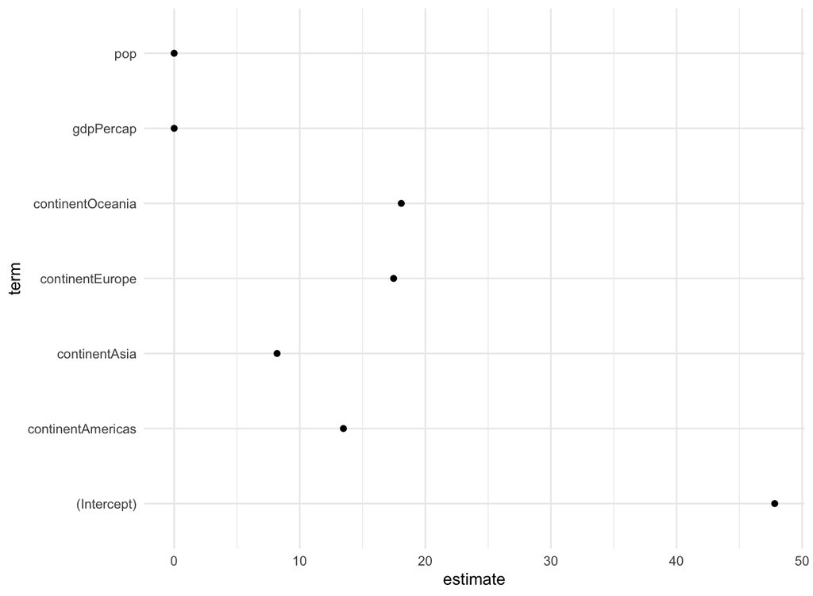

## Get component-level statistics with `tidy()`

- We can tell `tidy()` to calculate confidence intervals for the estimates, using R’s `conf.int = TRUE` option.

```r
out_conf <- tidy(out, conf.int = TRUE)
out_conf %>% round_df()
```

```
## # A tibble: 7 × 7
##   term              estimate std.error statistic p.value conf.low conf.high
##   <chr>                <dbl>     <dbl>     <dbl>   <dbl>    <dbl>     <dbl>
## 1 (Intercept)          47.8       0.34    141.         0    47.2      48.5
## 2 gdpPercap             0         0        19.2        0     0         0
## 3 pop                   0         0         3.33       0     0         0
## 4 continentAmericas    13.5       0.6      22.5        0    12.3      14.6
## 5 continentAsia         8.19      0.57     14.3        0     7.07      9.31
## 6 continentEurope      17.5       0.62     28.0        0    16.2      18.7
## 7 continentOceania     18.1       1.78     10.2        0    14.6      21.6
```

## Get component-level statistics with `tidy()`

- We can tell `tidy()` to calculate confidence intervals for the estimates, using R’s `conf.int = TRUE` option.

```r
out_conf <- subset(out_conf, term != "(Intercept)")
out_conf$nicelabs <- prefix_strip(out_conf$term, "continent")
```

## Get component-level statistics with `tidy()`

- We can use `geom_pointrange()` to make a figure that displays some information about our confidence in the variable estimates

```r
p <- ggplot(out_conf, mapping = aes(x = reorder(nicelabs, estimate),
                                    y = estimate, ymin = conf.low, ymax = conf.high))
p + geom_pointrange() + coord_flip() + labs(x="", y="OLS Estimate")
```

## Get component-level statistics with `tidy()`

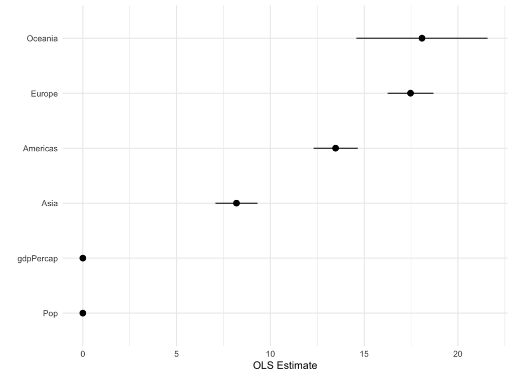

## Get observation-level statistics with `augment()`

```r
out_aug <- augment(out)
head(out_aug)
```

```
## # A tibble: 6 × 10
##   lifeExp gdpPercap      pop continent .fitted .resid    .hat .sigma .cooksd
##     <dbl>     <dbl>    <int> <fct>       <dbl>  <dbl>   <dbl>  <dbl>   <dbl>
## 1    28.8      779.  8425333 Asia         56.4  -27.6 0.00322   8.34 0.00505
## 2    30.3      821.  9240934 Asia         56.4  -26.1 0.00321   8.34 0.00450
## 3    32.0      853. 10267083 Asia         56.5  -24.5 0.00320   8.35 0.00393
## 4    34.0      836. 11537966 Asia         56.5  -22.4 0.00319   8.35 0.00330
## 5    36.1      740. 13079460 Asia         56.4  -20.3 0.00319   8.35 0.00271
## 6    38.4      786. 14880372 Asia         56.5  -18.0 0.00317   8.36 0.00212
## # … with 1 more variable: .std.resid <dbl>
```

```r
head(out_aug) %>% round_df()
```

```
## # A tibble: 6 × 10
##   lifeExp gdpPercap      pop continent .fitted .resid  .hat .sigma .cooksd
##     <dbl>     <dbl>    <dbl> <fct>       <dbl>  <dbl> <dbl>  <dbl>   <dbl>
## 1    28.8      779.  8425333 Asia         56.4  -27.6     0   8.34    0.01
## 2    30.3      821.  9240934 Asia         56.4  -26.1     0   8.34    0
## 3    32        853. 10267083 Asia         56.5  -24.5     0   8.35    0
## 4    34.0      836. 11537966 Asia         56.5  -22.4     0   8.35    0
## 5    36.1      740. 13079460 Asia         56.4  -20.3     0   8.35    0
## 6    38.4      786. 14880372 Asia         56.5  -18.0     0   8.36    0
## # … with 1 more variable: .std.resid <dbl>
```

## Get observation-level statistics with `augment()`

- The new columns created by `augment()` can be used to create some standard regression plots.
  - We can draw the residual plot (the residuals versus the fitted values).

```r
p <- ggplot(data = out_aug,
            mapping = aes(x = .fitted, y = .resid))
p + geom_point()
```

## Get observation-level statistics with `augment()`

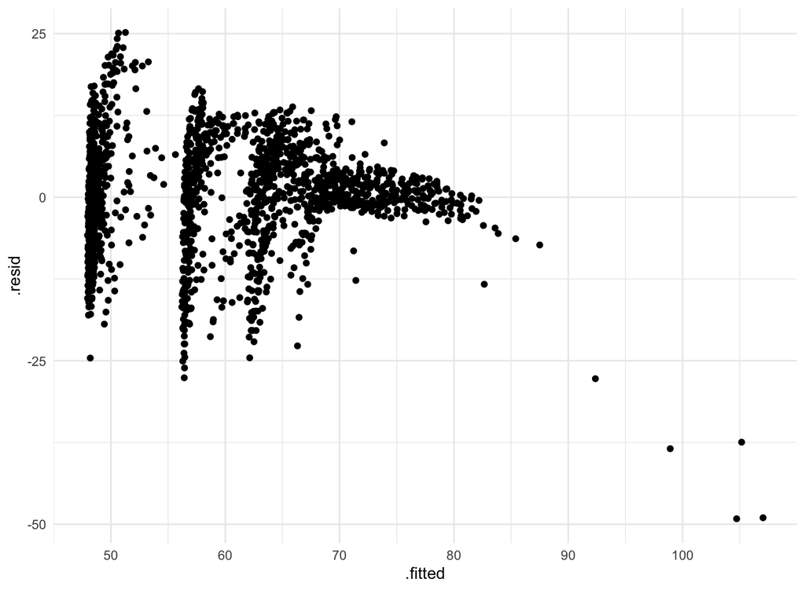

## Get model-level statistics with `glance()`

- `glance()` returns the information typically presented at the bottom of a model’s `summary()` output.

```r
glance(out) %>% round_df()
```

```
## # A tibble: 1 × 12
##   r.squared adj.r.squared sigma statistic p.value    df logLik    AIC    BIC
##       <dbl>         <dbl> <dbl>     <dbl>   <dbl> <dbl>  <dbl>  <dbl>  <dbl>
## 1      0.58          0.58  8.37      394.       0     6 -6034. 12084. 12127.
## # … with 3 more variables: deviance <dbl>, df.residual <dbl>, nobs <dbl>
```

## Grouped analysis and list columns

- Consider the linear regression model for the relationship between life expectancy and GDP by continent, for each year in the data.

```r
eu77 <- gapminder %>% filter(continent == "Europe", year == 1977)
fit <- lm(lifeExp ~ log(gdpPercap), data = eu77)
summary(fit)
```

```
##
## Call:
## lm(formula = lifeExp ~ log(gdpPercap), data = eu77)
##
## Residuals:
##     Min      1Q  Median      3Q     Max
## -7.4956 -1.0306  0.0935  1.1755  3.7125
##
## Coefficients:
##                Estimate Std. Error t value Pr(>|t|)
## (Intercept)      29.489      7.161   4.118 0.000306 ***
## log(gdpPercap)    4.488      0.756   5.936 2.17e-06 ***
## ---
## Signif. codes:  0 '***' 0.001 '**' 0.01 '*' 0.05 '.' 0.1 ' ' 1
##
## Residual standard error: 2.114 on 28 degrees of freedom
## Multiple R-squared:  0.5572, Adjusted R-squared:  0.5414
## F-statistic: 35.24 on 1 and 28 DF,  p-value: 2.173e-06
```

## Grouped analysis and list columns

- With `dplyr` and `broom` we can do the grouped analysis for every continent-year slice of the data in a compact and tidy way.

```r
out_le <- gapminder %>%
    group_by(continent, year) %>%
    nest()
out_le
```

```
## # A tibble: 60 × 3
## # Groups:   continent, year [60]
##    continent  year data
##    <fct>     <int> <list>
##  1 Asia       1952 <tibble [33 × 4]>
##  2 Asia       1957 <tibble [33 × 4]>
##  3 Asia       1962 <tibble [33 × 4]>
##  4 Asia       1967 <tibble [33 × 4]>
##  5 Asia       1972 <tibble [33 × 4]>
##  6 Asia       1977 <tibble [33 × 4]>
##  7 Asia       1982 <tibble [33 × 4]>
##  8 Asia       1987 <tibble [33 × 4]>
##  9 Asia       1992 <tibble [33 × 4]>
## 10 Asia       1997 <tibble [33 × 4]>
## # … with 50 more rows
```

- `nest()` creates a list-column of data frames.
  - The list column, `data`, contains a small table of data corresponding to each continent-year group.

## Grouped analysis and list columns

- We can look at specific group, for example, “Europe 1977”, if we like, by filtering the data and then unnesting the list column.

```r
out_le %>% filter(continent == "Europe" & year == 1977) %>%
  unnest()
```

```
## # A tibble: 30 × 6
## # Groups:   continent, year [1]
##    continent  year country                lifeExp      pop gdpPercap
##    <fct>     <int> <fct>                    <dbl>    <int>     <dbl>
##  1 Europe     1977 Albania                   68.9  2509048     3533.
##  2 Europe     1977 Austria                   72.2  7568430    19749.
##  3 Europe     1977 Belgium                   72.8  9821800    19118.
##  4 Europe     1977 Bosnia and Herzegovina    69.9  4086000     3528.
##  5 Europe     1977 Bulgaria                  70.8  8797022     7612.
##  6 Europe     1977 Croatia                   70.6  4318673    11305.
##  7 Europe     1977 Czech Republic            70.7 10161915    14800.
##  8 Europe     1977 Denmark                   74.7  5088419    20423.
##  9 Europe     1977 Finland                   72.5  4738902    15605.
## 10 Europe     1977 France                    73.8 53165019    18293.
## # … with 20 more rows
```

## Grouped analysis and list columns

- List columns are useful because we can act on them in a compact and tidy way.

```r
fit_ols <- function(df) {
    lm(lifeExp ~ log(gdpPercap), data = df)
}

out_le <- gapminder %>%
    group_by(continent, year) %>%
    nest() %>%
    mutate(model = map(data, fit_ols))

out_le
```

```
## # A tibble: 60 × 4
## # Groups:   continent, year [60]
##    continent  year data              model
##    <fct>     <int> <list>            <list>
##  1 Asia       1952 <tibble [33 × 4]> <lm>
##  2 Asia       1957 <tibble [33 × 4]> <lm>
##  3 Asia       1962 <tibble [33 × 4]> <lm>
##  4 Asia       1967 <tibble [33 × 4]> <lm>
##  5 Asia       1972 <tibble [33 × 4]> <lm>
##  6 Asia       1977 <tibble [33 × 4]> <lm>
##  7 Asia       1982 <tibble [33 × 4]> <lm>
##  8 Asia       1987 <tibble [33 × 4]> <lm>
##  9 Asia       1992 <tibble [33 × 4]> <lm>
## 10 Asia       1997 <tibble [33 × 4]> <lm>
## # … with 50 more rows
```

- `map()` function applies a function to each element of a vector.

## Grouped analysis and list columns

- List columns are useful because we can act on them in a compact and tidy way.

```r
fit_ols <- function(df) {
    lm(lifeExp ~ log(gdpPercap), data = df)
}

out_tidy <- gapminder %>%
    group_by(continent, year) %>%
    nest() %>%
    mutate(model = map(data, fit_ols),
           tidied = map(model, tidy)) %>%
    unnest(tidied, .drop = TRUE) %>%
    filter(term != "(Intercept)" &
           continent != "Oceania")
```

## Grouped analysis and list columns

- We now have tidy regression output with an estimate of the association between log GDP per capita and life expectancy *for each year*, *within continents*.

```r
p <- ggplot(data = out_tidy,
            mapping = aes(x = year, y = estimate,
                          ymin = estimate - 2*std.error,
                          ymax = estimate + 2*std.error,
                          group = continent, color = continent))

p + geom_pointrange(position = position_dodge(width = 1)) +
    scale_x_continuous(breaks = unique(gapminder$year)) +
    theme(legend.position = "top") +
    labs(x = "Year", y = "Estimate", color = "Continent")
```

## Grouped analysis and list columns

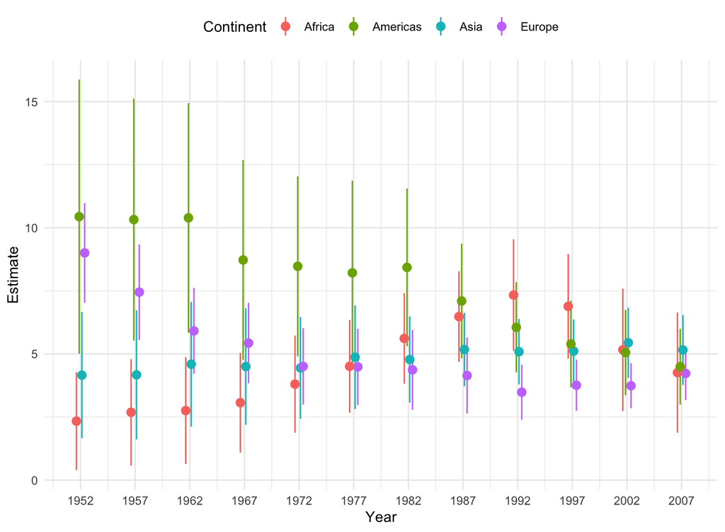